# HR Analysis: job chance of Data Scientists

Machine Learning, A.A. 2020/2021

Members: Hooshyar Hosna, Lorefice Alessandra

# Table of Contents

## Introduction

### Libraries

```python
#general
import pandas as pd
import numpy as np

#preprocessing
import copy
from collections import defaultdict
from sklearn.preprocessing import LabelEncoder
from sklearn.model_selection import train_test_split

#Validation
from sklearn.model_selection import GridSearchCV

#information gain
from sklearn.feature_selection import mutual_info_classif

#pca and famd
from sklearn.decomposition import PCA
from light_famd import FAMD

#SVM
from sklearn.svm import SVC
from sklearn import metrics
import time
from datetime import timedelta
from tabulate import tabulate

#Random Forest
from sklearn.ensemble import RandomForestClassifier

#Neural Network
import tensorflow as tf
from tensorflow import keras
from tensorflow.keras import layers
from tensorflow.keras.callbacks import History
from tensorflow.keras.wrappers.scikit_learn import KerasClassifier

#plot
import seaborn as sns
import matplotlib.pyplot as plt
%matplotlib inline
from mpl_toolkits import mplot3d
import matplotlib.style as style

#evaluation
from sklearn.metrics import confusion_matrix, accuracy_score
from sklearn.datasets import load_digits
from sklearn.model_selection import learning_curve


#scaling
from sklearn.preprocessing import StandardScaler

#warnings
import warnings
warnings.filterwarnings('ignore')
```

### Motivations

We decided to analyse this dataset mainly because we were interested in the topic. We wanted to work with some data that could be both interesting and useful for us, so we found that this one was a perfect choice for our needs.

Additionally, we wanted to work with a dataset with a huge number of rows that could have been good material for preprocessing, one of the most important part of our project.

### Exploring the Dataset

Let us start by exploring the features of our dataset. In the following lines, we analysed each feature (except made for city) in respect to the target. Indeed, we could have been aware of some correlations between them.

```python
dataFrame = pd.read_csv('data\cleaned_train.csv')
clean_df = dataFrame.dropna()
clean_df.head(5)
```

|  | enrollee_id | city | city_development_index | gender | relevent_experience | enrolled_university | education_level | major_discipline | experience | company_size | company_type | last_new_job | training_hours | target |
| --- | --- | --- | --- | --- | --- | --- | --- | --- | --- | --- | --- | --- | --- | --- |
| 0 | 8949 | city_103 | 0.920 | Male | 1 | no_enrollment | Graduate | STEM | >20 | 100-500 | Pvt Ltd | 1 | 36 | 1.0 |
| 1 | 29725 | city_40 | 0.776 | Male | 0 | no_enrollment | Graduate | STEM | 15 | 50-99 | Pvt Ltd | >4 | 47 | 0.0 |
| 2 | 11561 | city_21 | 0.624 | Male | 0 | Full time course | Graduate | STEM | 5 | 10000+ | Pvt Ltd | never | 83 | 0.0 |
| 3 | 33241 | city_115 | 0.789 | Male | 0 | no_enrollment | Graduate | Business Degree | <1 | <10 | Pvt Ltd | never | 52 | 1.0 |
| 4 | 666 | city_162 | 0.767 | Male | 1 | no_enrollment | Masters | STEM | >20 | 50-99 | Funded Startup | 4 | 8 | 0.0 |

This dataset has the aim to predict the possibility of a person to change his or her job to became a data scientist.

After the cleaning made by replacing missing values, our dataset has the following structure:

The target column represent the label that we want to predict. It can be 0 or 1 where:

- 0 = the subject does not look for a new job as data scientist;
- 1 = the subject is looking for a new job as data scientist.

Before starting analysis, it could be useful to look at the distribution of the target among the different features. This is also a good way to visualize our dataset for being aware of any unbalancement that may influence our analysis.

```python
def plotPercentageByTarget(data, column, x_label=None, x_ticks=None):

    '''
    Take as input the dataframe and one column as string and print the bar plot
    of percentage of that column in the dataframe according to the target.
    In addition it takes the name to give to x axis and the labels for x ticks

    '''

    #create percentages
    temp = pd.DataFrame(data[[column, 'target']].groupby([column, 'target'])['target'].count())
    temp = temp.rename(columns={'target':'perc'})
    temp['perc'] = (temp['perc']*100)/len(data)
    temp = temp.reset_index().rename(columns={column:'column', 'target':'target'})
    temp = pd.DataFrame(temp)
    temp['target'] = temp['target'].replace([0.0, 1.0],
                                            ["Do not look for a new job", "Look for a new job" ])

    #plot
    fig = plt.figure(figsize=[8,5])
    sns.barplot(x='column', y='perc', hue='target', alpha=1, data=temp)

    #labels
    if x_label is None:
        x_label = column.capitalize()

    plt.title("Percentage of {} by target".format(x_label.lower()), fontsize=16)

    plt.xlabel(x_label, fontsize=14)
    plt.xticks(fontsize=12)
    if x_ticks is not None:
        plt.xticks(ticks=range(0,len(x_ticks),1), labels=x_ticks)

    plt.ylabel("%", fontsize=14)
    plt.yticks(fontsize=12)

    plt.legend(title="Target", title_fontsize=14, fontsize=12, labelspacing= 0.8,
               borderpad=0.9, shadow=True, loc='best')
```

#### Target

Among all the fetures, this is for sure the most important. For this reason let's see how different targets are distribuited into the dataset.

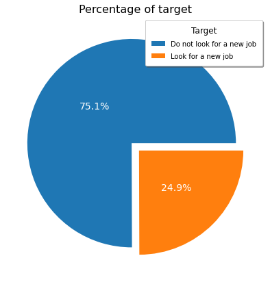

```python
#plot
fig = plt.figure(figsize=[10,7])
plt.pie(x=clean_df['target'].value_counts(normalize=True), textprops={'fontsize':14, 'color':'white'},
        autopct="%.1f%%", explode=[0.05]*2, pctdistance=0.5)

#labels
plt.legend(title="Target", labels=["Do not look for a new job", "Look for a new job" ],
           title_fontsize=12, fontsize=10, labelspacing= 0.8,
               borderpad=0.9, shadow=True, loc='best')


plt.title("Percentage of target", fontsize=16);
```

Thus, or labels are not balanced among the dataset. This could influence our analysis since it will be more probable to predict value 0 instead of value 1.

#### Gender

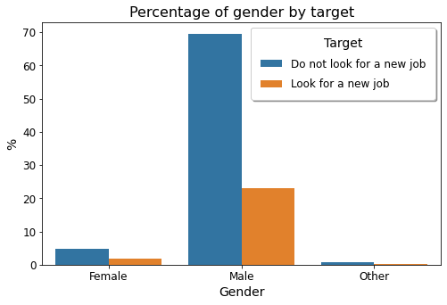

```python
plotPercentageByTarget(clean_df, 'gender')
```

As we can see from the graphics, the percentage of male is predominant. This fact could effect our analysis because just a little percentage of female is going to change the job, so the algorithm will be biased based on gender.

A more appropriate choice for this company that wanted this prediction algorithm, should have been to choose a sample of people with the same gender number.

#### City Development Index

The city development index measures the level of development in cities. It has a value between 0 and 1 and it is computed by using separate sub-indices for Infrastructure, Waste Management, Health, Education, and City Product, which are averaged to form it.

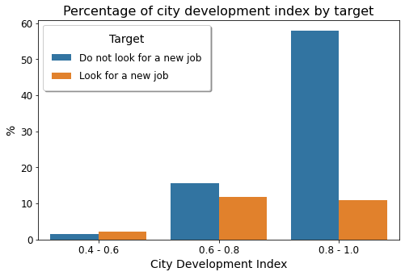

```python
#create categories for the rappresentation in the graphic
city_categories = []

for value in clean_df['city_development_index']:
    if value>=0.40 and value<0.60:
        city_categories.append("0.4 - 0.6")
    elif value>=0.60 and value<0.80:
        city_categories.append("0.6 - 0.8")
    elif value>=0.80 and value<1.0:
        city_categories.append("0.8 - 1.0")

temp_city = copy.deepcopy(clean_df)
temp_city['city_categ'] = city_categories

#plot
plotPercentageByTarget(temp_city, 'city_categ', 'City Development Index')
```

#### Relevent Experience

The relevant experience feature says whether a person has had some work experience in data science.

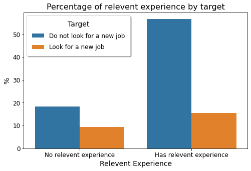

```python
plotPercentageByTarget(clean_df, 'relevent_experience', 'Relevent Experience',
                       x_ticks=['No relevent experience', 'Has relevent experience'])
```

#### Enrolled University

The feaure enrolled university says whether a person is studying at university in that moment. In particular, it specifies also the type of enrollment (full time or part time).

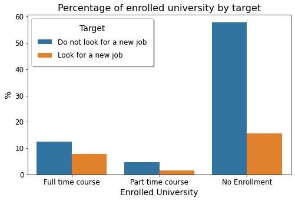

```python
plotPercentageByTarget(clean_df, 'enrolled_university', 'Enrolled University',
                      ["Full time course", "Part time course", "No Enrollment"])
```

#### Education Level

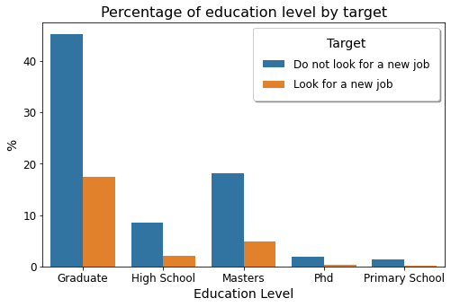

```python
plotPercentageByTarget(clean_df, 'education_level', 'Education Level')
```

#### Major Discipline

We interpreted the major discipline as the field of study of a university. Ideed, we noticed that High School and Primary School are always considered in pairs with "No Major".

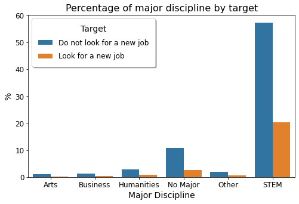

```python
plotPercentageByTarget(clean_df, 'major_discipline', 'Major Discipline',
                       ['Arts', 'Business', 'Humanities', 'No Major', 'Other', 'STEM'])
```

#### Experience

The feature experience contains the years of work experience of a subject. For showing them in a clean way, we decided to build fouer main categories:

- less than 1 year;
- between 1 and 10 years;
- between 11 and 20 years;
- more than 20 years.

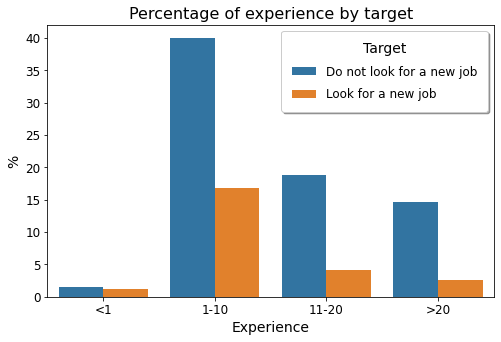

```python
#create categories for the rappresentation in the graphic
exp_categories = []

for value in clean_df['experience']:
    if value == "<1":
        exp_categories.append("0")
    elif value in ["<1", "1", "2", "3", "4", "5", "6", "7", "8", "9", "10"]:
        exp_categories.append("0-10")
    elif value in ["11", "12", "13", "14", "15", "16", "17", "18", "19", "20"]:
        exp_categories.append("11-20")
    elif value == ">20":
        exp_categories.append(">20")

temp_exp = copy.deepcopy(clean_df)
temp_exp['exp_categ'] = exp_categories

#plot
plotPercentageByTarget(temp_exp, 'exp_categ', 'Experience', ["<1", "1-10", "11-20", ">20"])
```

#### Company Type

The company type values specify the type of the last company the subject has worked for. The possibilities are

- NGO;
- Public Sector;
- Pvt Ltd;
- Startup;
- Other.

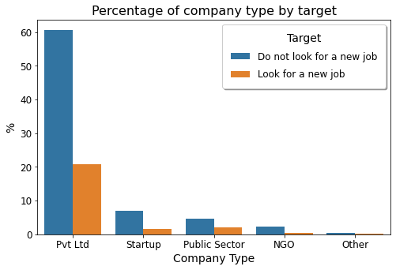

```python
#merge startup values
ct_categories = []

for value in clean_df['company_type']:
    if value == "Pvt Ltd":
        ct_categories.append(1)
    elif value in ["Early Stage Startup", "Funded Startup"]:
        ct_categories.append(2)
    elif value == "Public Sector":
        ct_categories.append(3)
    elif value == "NGO":
        ct_categories.append(4)
    elif value == "Other":
        ct_categories.append(5)


temp_ct = copy.deepcopy(clean_df)
temp_ct['ct_categ'] = ct_categories

#plot
plotPercentageByTarget(temp_ct, 'ct_categ', 'Company Type',
                       ["Pvt Ltd", "Startup", "Public Sector", "NGO", "Other"])
```

#### Comapny Size

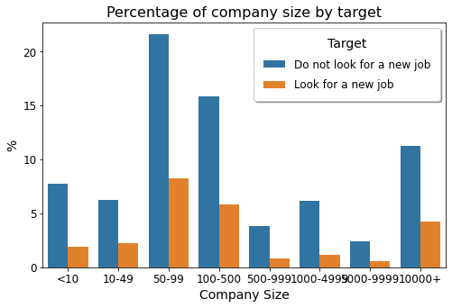

```python
#create catgories for company size
cs_categories = []

for value in clean_df['company_size']:
    if value == "<10":
        cs_categories.append(1)
    elif value == "10/49":
        cs_categories.append(2)
    elif value == "50-99":
        cs_categories.append(3)
    elif value == "100-500":
        cs_categories.append(4)
    elif value == "500-999":
        cs_categories.append(5)
    elif value == "1000-4999":
        cs_categories.append(6)
    elif value == "5000-9999":
        cs_categories.append(7)
    elif value == "10000+":
        cs_categories.append(8)

temp_cs = copy.deepcopy(clean_df)
temp_cs['cs_categ'] = cs_categories

#plot
plotPercentageByTarget(temp_cs, 'cs_categ', 'Company Size',
                      ["<10", "10-49", "50-99", "100-500", "500-999", "1000-4999", "5000-9999", "10000+"])
```

#### Last New Job

These values represent the years last from when a subject change his or her last job.

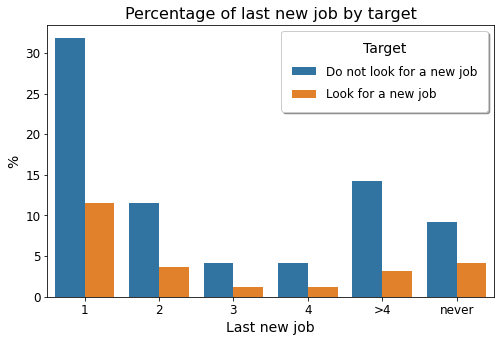

```python
plotPercentageByTarget(clean_df, 'last_new_job', 'Last new job')
```

#### Training Hours

In this feature we find the amount of hours the company spent to train the subject. Again, we have a lot of different values, thus, for showing them we create the categories

- between 1 and 99 hours;
- betweend 100 and 199 hours;
- between 200 and 300 hours;
- more than 300 hours.

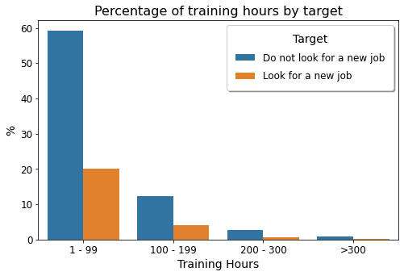

```python
#create categories for training hours
th_categories = []

for value in clean_df['training_hours']:
    if value>=1.0 and value<100.0:
        th_categories.append("1 - 99")
    elif value>=100.0 and value<200.0:
        th_categories.append("100 - 199")
    elif value>=200.0 and value<=300.0:
        th_categories.append("200 - 300")
    elif value>300.0:
        th_categories.append(">300")

temp_th = copy.deepcopy(clean_df)
temp_th['th_categ'] = th_categories

#plot
plotPercentageByTarget(temp_th, 'th_categ', 'Training Hours')
```

## Preprocessing

Data preprocessing is an integral step in machine learning as the quality of data and the useful information that can be derived from it directly affects the ability of our model to learn; therefore, it is extremely important that we preprocess our data before feeding it into our model.

To do so, we chose two distinct ways:

- Information Gain: by using this preprocessing algorithm we choose features that give the biggest number of information. Thus, it is a process that *selects* existing features;
- PCA and FAMD: this algorithm creates different features basing on the existing ones.

This two ways give us the possibility to see the differences between *select* and *create* according to the accuracy of the prediction in classification algorithms.

### How handle categorical values?

Since our dataset is mainly made of categorical values, we needed to convert them into numeric values in order to analyze them. Since we found different methods of doing that, each one with its pros and cons, we decided to choose two of them and analyze the differences that this choice may have caused. These two methods are:

- Dummy values
- Label encoding

Although it was said that these two methods will be used, the columns and their values show that it may not be needed for all of them. Some of these features have a numerical nature and their values can be replaced by some modifications. For example, the values of the *company_size* column are ranges of numbers that can be simply replaced by the mean of the range.

```python
def replace_fun(dataFrame, column, current_value, new_value):

    '''
    column is the name of the column that we want to replace its values.
    '''

    dataFrame[column] = np.where(
        dataFrame[column] == current_value, new_value, dataFrame[column])
```

```python
def convert_to_float(dataFrame, column):
        dataFrame[column] = dataFrame[column].astype(float)
```

```python
final_df = copy.deepcopy(clean_df)
df_category = final_df.select_dtypes(include='object')
df_category.columns
```

```
Index(['city', 'gender', 'enrolled_university', 'education_level',
       'major_discipline', 'experience', 'company_size', 'company_type',
       'last_new_job'],
      dtype='object')
```

```python
#Replacing the values of company_size column
replace_fun(final_df,'company_size','<10',4.5)
replace_fun(final_df,'company_size','10/49',29.5)
replace_fun(final_df,'company_size','50-99',74.5)
replace_fun(final_df,'company_size','100-500',299.5)
replace_fun(final_df,'company_size','500-999',749.5)
replace_fun(final_df,'company_size','1000-4999',2999.5)
replace_fun(final_df,'company_size','5000-9999',7499.5)
replace_fun(final_df,'company_size','10000+',29999.5)

convert_to_float(final_df,'company_size')
```

```python
#Replacing the values of experience column
replace_fun(final_df,'experience','>20',21)
replace_fun(final_df,'experience','<1',0)
#Only these two values needed to be replaced

convert_to_float(final_df,'experience')
```

```python
#Replacing the values of last_new_job column
replace_fun(final_df,'last_new_job','>4',5)
replace_fun(final_df,'last_new_job','never',0)

convert_to_float(final_df,'last_new_job')
```

```python
final_df.head(5)
```

|  | enrollee_id | city | city_development_index | gender | relevent_experience | enrolled_university | education_level | major_discipline | experience | company_size | company_type | last_new_job | training_hours | target |
| --- | --- | --- | --- | --- | --- | --- | --- | --- | --- | --- | --- | --- | --- | --- |
| 0 | 8949 | city_103 | 0.920 | Male | 1 | no_enrollment | Graduate | STEM | 21.0 | 299.5 | Pvt Ltd | 1.0 | 36 | 1.0 |
| 1 | 29725 | city_40 | 0.776 | Male | 0 | no_enrollment | Graduate | STEM | 15.0 | 74.5 | Pvt Ltd | 5.0 | 47 | 0.0 |
| 2 | 11561 | city_21 | 0.624 | Male | 0 | Full time course | Graduate | STEM | 5.0 | 29999.5 | Pvt Ltd | 0.0 | 83 | 0.0 |
| 3 | 33241 | city_115 | 0.789 | Male | 0 | no_enrollment | Graduate | Business Degree | 0.0 | 4.5 | Pvt Ltd | 0.0 | 52 | 1.0 |
| 4 | 666 | city_162 | 0.767 | Male | 1 | no_enrollment | Masters | STEM | 21.0 | 74.5 | Funded Startup | 4.0 | 8 | 0.0 |

#### Dummy values

The first strategy we adpoted was to convert our data using *dummy values*.

A **dummy variable** is a numeric variable that represents categorical data. The number of dummy variables required to represent a particular categorical variable depends on the number of values that the categorical variable can assume. [Source](https://stattrek.com/multiple-regression/dummy-variables.aspx)

This picture shows how dummy values work.

[figure not shown]

```python
dummy_df = copy.deepcopy(final_df)
df_category = dummy_df.select_dtypes(include='object')
df_numeric = dummy_df.select_dtypes(exclude='object')
df_category_dummies = pd.get_dummies(df_category)
frames = [df_numeric, df_category_dummies]
dummy_df = pd.concat(frames, axis=1,join='inner')
dummy_df.head(5)
```

|  | enrollee_id | city_development_index | relevent_experience | experience | company_size | last_new_job | training_hours | target | city_city_1 | city_city_10 | ... | major_discipline_Humanities | major_discipline_No Major | major_discipline_Other | major_discipline_STEM | company_type_Early Stage Startup | company_type_Funded Startup | company_type_NGO | company_type_Other | company_type_Public Sector | company_type_Pvt Ltd |
| --- | --- | --- | --- | --- | --- | --- | --- | --- | --- | --- | --- | --- | --- | --- | --- | --- | --- | --- | --- | --- | --- |
| 0 | 8949 | 0.920 | 1 | 21.0 | 299.5 | 1.0 | 36 | 1.0 | 0 | 0 | ... | 0 | 0 | 0 | 1 | 0 | 0 | 0 | 0 | 0 | 1 |
| 1 | 29725 | 0.776 | 0 | 15.0 | 74.5 | 5.0 | 47 | 0.0 | 0 | 0 | ... | 0 | 0 | 0 | 1 | 0 | 0 | 0 | 0 | 0 | 1 |
| 2 | 11561 | 0.624 | 0 | 5.0 | 29999.5 | 0.0 | 83 | 0.0 | 0 | 0 | ... | 0 | 0 | 0 | 1 | 0 | 0 | 0 | 0 | 0 | 1 |
| 3 | 33241 | 0.789 | 0 | 0.0 | 4.5 | 0.0 | 52 | 1.0 | 0 | 0 | ... | 0 | 0 | 0 | 0 | 0 | 0 | 0 | 0 | 0 | 1 |
| 4 | 666 | 0.767 | 1 | 21.0 | 74.5 | 4.0 | 8 | 0.0 | 0 | 0 | ... | 0 | 0 | 0 | 1 | 0 | 1 | 0 | 0 | 0 | 0 |

5 rows × 154 columns

After trying algorithms and preprocessing to the dataset with dummy values and label enconding one, we noticed that there was not so much difference in the results. Thus we will keep just the dataset with dummy values since we found that using dummies should be more correct conceptually.

#### Label encoding

The second strategy was a simple *label encoding*. Label Encoding refers to converting the labels into numeric form so as to convert it into the machine-readable form. Machine learning algorithms can then decide in a better way on how those labels must be operated. This way to go can have the disadvantage o being misunderstand by the algorithm but it does not change the number of columns. [Source](https://www.geeksforgeeks.org/ml-label-encoding-of-datasets-in-python/)

[figure not shown]

```python
labenc_df = copy.deepcopy(final_df)
```

```python
df_category = final_df.select_dtypes(include='object')
df_category
```

|  | city | gender | enrolled_university | education_level | major_discipline | company_type |
| --- | --- | --- | --- | --- | --- | --- |
| 0 | city_103 | Male | no_enrollment | Graduate | STEM | Pvt Ltd |
| 1 | city_40 | Male | no_enrollment | Graduate | STEM | Pvt Ltd |
| 2 | city_21 | Male | Full time course | Graduate | STEM | Pvt Ltd |
| 3 | city_115 | Male | no_enrollment | Graduate | Business Degree | Pvt Ltd |
| 4 | city_162 | Male | no_enrollment | Masters | STEM | Funded Startup |
| ... | ... | ... | ... | ... | ... | ... |
| 19079 | city_173 | Male | no_enrollment | Graduate | Humanities | Pvt Ltd |
| 19080 | city_103 | Male | no_enrollment | Graduate | STEM | Pvt Ltd |
| 19081 | city_103 | Male | no_enrollment | Graduate | STEM | Pvt Ltd |
| 19082 | city_65 | Male | no_enrollment | High School | No Major | Pvt Ltd |
| 19083 | city_67 | Male | no_enrollment | Primary School | No Major | Pvt Ltd |

19084 rows × 6 columns

```python
df_numeric = final_df.select_dtypes(exclude='object')
df_numeric
```

|  | enrollee_id | city_development_index | relevent_experience | experience | company_size | last_new_job | training_hours | target |
| --- | --- | --- | --- | --- | --- | --- | --- | --- |
| 0 | 8949 | 0.920 | 1 | 21.0 | 299.5 | 1.0 | 36 | 1.0 |
| 1 | 29725 | 0.776 | 0 | 15.0 | 74.5 | 5.0 | 47 | 0.0 |
| 2 | 11561 | 0.624 | 0 | 5.0 | 29999.5 | 0.0 | 83 | 0.0 |
| 3 | 33241 | 0.789 | 0 | 0.0 | 4.5 | 0.0 | 52 | 1.0 |
| 4 | 666 | 0.767 | 1 | 21.0 | 74.5 | 4.0 | 8 | 0.0 |
| ... | ... | ... | ... | ... | ... | ... | ... | ... |
| 19079 | 7386 | 0.878 | 0 | 14.0 | 74.5 | 1.0 | 42 | 1.0 |
| 19080 | 31398 | 0.920 | 1 | 14.0 | 74.5 | 4.0 | 52 | 1.0 |
| 19081 | 24576 | 0.920 | 1 | 21.0 | 74.5 | 4.0 | 44 | 0.0 |
| 19082 | 5756 | 0.802 | 1 | 0.0 | 749.5 | 2.0 | 97 | 0.0 |
| 19083 | 23834 | 0.855 | 0 | 2.0 | 74.5 | 1.0 | 127 | 0.0 |

19084 rows × 8 columns

```python
#maps all categorical data into strings
for i in labenc_df.columns:
    if i in df_category.columns:
        labenc_df[i] = labenc_df[i].map(str)
labenc_df.drop(columns=df_numeric.columns,inplace=True)

#converting categorical data in numerical data
d = defaultdict(LabelEncoder)
labenc_df = labenc_df.apply(lambda x: d[x.name].fit_transform(x))

labenc_df[df_numeric.columns] = df_numeric
labenc_df = labenc_df[clean_df.columns]
```

```python
labenc_df
```

|  | enrollee_id | city | city_development_index | gender | relevent_experience | enrolled_university | education_level | major_discipline | experience | company_size | company_type | last_new_job | training_hours | target |
| --- | --- | --- | --- | --- | --- | --- | --- | --- | --- | --- | --- | --- | --- | --- |
| 0 | 8949 | 5 | 0.920 | 1 | 1 | 2 | 0 | 5 | 21.0 | 299.5 | 5 | 1.0 | 36 | 1.0 |
| 1 | 29725 | 77 | 0.776 | 1 | 0 | 2 | 0 | 5 | 15.0 | 74.5 | 5 | 5.0 | 47 | 0.0 |
| 2 | 11561 | 64 | 0.624 | 1 | 0 | 0 | 0 | 5 | 5.0 | 29999.5 | 5 | 0.0 | 83 | 0.0 |
| 3 | 33241 | 14 | 0.789 | 1 | 0 | 2 | 0 | 1 | 0.0 | 4.5 | 5 | 0.0 | 52 | 1.0 |
| 4 | 666 | 50 | 0.767 | 1 | 1 | 2 | 2 | 5 | 21.0 | 74.5 | 1 | 4.0 | 8 | 0.0 |
| ... | ... | ... | ... | ... | ... | ... | ... | ... | ... | ... | ... | ... | ... | ... |
| 19079 | 7386 | 55 | 0.878 | 1 | 0 | 2 | 0 | 2 | 14.0 | 74.5 | 5 | 1.0 | 42 | 1.0 |
| 19080 | 31398 | 5 | 0.920 | 1 | 1 | 2 | 0 | 5 | 14.0 | 74.5 | 5 | 4.0 | 52 | 1.0 |
| 19081 | 24576 | 5 | 0.920 | 1 | 1 | 2 | 0 | 5 | 21.0 | 74.5 | 5 | 4.0 | 44 | 0.0 |
| 19082 | 5756 | 94 | 0.802 | 1 | 1 | 2 | 1 | 3 | 0.0 | 749.5 | 5 | 2.0 | 97 | 0.0 |
| 19083 | 23834 | 95 | 0.855 | 1 | 0 | 2 | 4 | 3 | 2.0 | 74.5 | 5 | 1.0 | 127 | 0.0 |

19084 rows × 14 columns

### Information Gain

Information gain can be used for feature selection, by evaluating the gain of each variable in the context of the target variable. In this usage, the calculation is referred to as mutual information between the two random variables.

```python
def infoGain (y_class,X_class,i,j):

    '''
    y_class: The value that we want to predict
    X_class: Predictors
    i and j: size of plot

    '''
    importance = mutual_info_classif(X_class, y_class)
    feature_importance = pd.Series(importance, index=X_class.columns)
    fig,ax = plt.subplots()
    fig.set_size_inches(i,j)
    ax.barh(feature_importance.sort_values().index, feature_importance.sort_values().values)
    plt.xticks(rotation=90)
    plt.title('Information Gain for each feature')
    plt.show()
    index_list = list(feature_importance.sort_values().index)
    value_list = list(feature_importance.sort_values().values)
    data_list = [index_list,value_list]
    dl = pd.DataFrame (data_list)
    dl = dl.T
    dl.columns = ['feature', 'info_gain']
    dl = dl.set_index('feature')
    dl.sort_values('info_gain', axis = 0, ascending = False,inplace = True)
    dl = dl.drop(dl[dl.info_gain < 0.005].index)
    plt.savefig('infogain.png')
    return dl
```

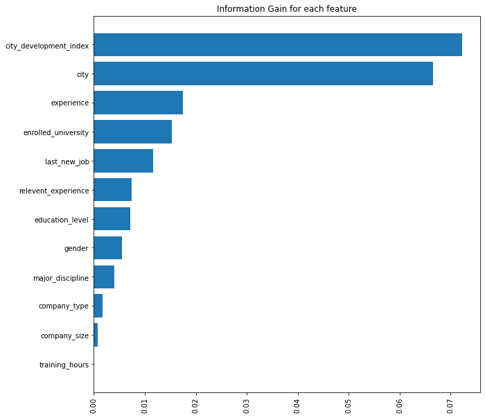

```python
y_class = labenc_df['target']
X_class = labenc_df.drop(['target','enrollee_id'],axis=1).copy()

info_gain_features = infoGain (y_class,X_class,10,10)
```

```python
info_gain_features
```

| feature | info_gain |
| --- | --- |
| city_development_index | 0.0722319 |
| city | 0.0665866 |
| experience | 0.0175382 |
| enrolled_university | 0.0152684 |
| last_new_job | 0.0115844 |
| relevent_experience | 0.00743936 |
| education_level | 0.00719058 |
| gender | 0.00553971 |

#### Most influential features

As it was mentioned before, what information gain algorithm does, is estimating mutual information for a discrete target variable. Mutual information (MI) between two random variables is a non-negative value, which measures the dependency between the variables. It is equal to zero if and only if two random variables are independent, and higher values mean higher dependency.

```python
ig_features = info_gain_features.index.tolist()
ig_features
```

```
['city_development_index',
 'city',
 'experience',
 'enrolled_university',
 'last_new_job',
 'relevent_experience',
 'education_level',
 'gender']
```

### PCA and FAMD

Since it is difficult to imagine the patterns behind the classification of our dataset, we decided to use a preprocessing algorithm that could give us the possibility of visualizing the fetures in 2-D according to the target. The best ways to have that is with PCA and FAMD. Indeed, with PCA and FAMD we don't need to *select* any feature but, instead, we can use all of them for *creating* new features to be analysed.

```python
dummy_X = dummy_df.drop(columns=["enrollee_id", "target"])
```

#### Principal Component Analysis

PCA is a good choice when our dataset is made of numerical data. Our original dataset does not satisfy this condition. However, we can use the dataset with dummy values that we have created before.

```python
pca = PCA(n_components=2)
```

As mentioned before, we wanted to build just two features in order plot them.

```python
#fit our dataset
pca.fit(dummy_X)
```

```
PCA(copy=True, iterated_power='auto', n_components=2, random_state=None,
    svd_solver='auto', tol=0.0, whiten=False)
```

Below it is shown the relevance of each original feature in respect of the new ones.

```python
temp_dict = dict()
temp_dict['Feature1'] = pca.components_[0]
temp_dict['Feature2'] = pca.components_[1]

pd.DataFrame(temp_dict)
```

|  | Feature1 | Feature2 |
| --- | --- | --- |
| 0 | 6.504909e-07 | 0.000007 |
| 1 | -4.818660e-06 | 0.000063 |
| 2 | 1.330156e-05 | 0.000184 |
| 3 | 1.000000e+00 | 0.000158 |
| 4 | 1.149275e-06 | -0.000151 |
| ... | ... | ... |
| 147 | -2.324882e-06 | 0.000012 |
| 148 | -4.790451e-07 | 0.000017 |
| 149 | 2.484678e-08 | 0.000006 |
| 150 | 1.963596e-06 | -0.000083 |
| 151 | 2.277843e-06 | 0.000024 |

152 rows × 2 columns

```python
print("The variance explained by each of the principal components is")
print(pca.explained_variance_)
```

```
The variance explained by each of the principal components is
[1.14849280e+08 3.60781184e+03]
```

```python
dummy_X_pca = pca.transform(dummy_X)

# checking that the original data has 152 dimensions
print("original shape:   ", dummy_X.shape)

# checking that the original data has 2 dimension
print("transformed shape:", dummy_X_pca.shape)
```

```
original shape:    (19084, 152)
transformed shape: (19084, 2)
```

```python
#build a new dataframe with the new features and add labels

X_pca_df = pd.DataFrame(dummy_X_pca)
X_pca_df['target'] = list(clean_df['target'])
X_pca_df = X_pca_df.rename(columns={0:'Feature1', 1:'Feature2'})
```

```python
#balance the target in plotting

f1 = []
f2 = []
targ = []

count_ones = 0
count_zeros = 0

for i in range(len(X_pca_df)):

    if count_ones == 500 and count_zeros == 500:
        break

    if X_pca_df.iloc[i, 2] == 0.0 and count_zeros < 500:
        count_zeros += 1
        f1.append(X_pca_df.iloc[i, 0])
        f2.append(X_pca_df.iloc[i, 1])
        targ.append(0.0)

    if X_pca_df.iloc[i, 2] == 1.0 and count_ones < 500:
        count_ones += 1
        f1.append(X_pca_df.iloc[i, 0])
        f2.append(X_pca_df.iloc[i, 1])
        targ.append(1.0)

temp_dic = dict()
temp_dic["Feature1"] = f1
temp_dic["Feature2"] = f2
temp_dic["target"] = targ

balanced_X_pca_df = pd.DataFrame(temp_dic)
balanced_X_pca_df.head(5)
```

|  | Feature1 | Feature2 | target |
| --- | --- | --- | --- |
| 0 | -4925.854783 | -30.150589 | 1.0 |
| 1 | -5150.856591 | -19.187877 | 0.0 |
| 2 | 24774.137228 | 21.525405 | 0.0 |
| 3 | -5220.857585 | -14.200906 | 1.0 |
| 4 | -5150.850375 | -58.186792 | 0.0 |

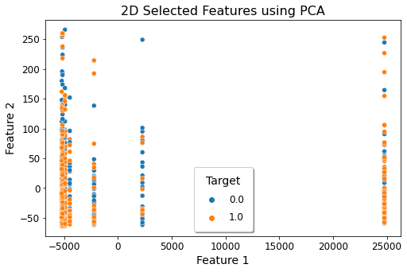

```python
fig = plt.figure(figsize=[8,5])
sns.scatterplot(x="Feature1", y="Feature2", hue='target',
                data=balanced_X_pca_df)

plt.title("2D Selected Features using PCA", fontsize=16)

plt.xlabel("Feature 1", fontsize=14)
plt.xticks(fontsize=12)
plt.ylabel("Feature 2", fontsize=14)
plt.yticks(fontsize=12)

plt.legend(title="Target", title_fontsize=14, fontsize=12, labelspacing= 0.8,
               borderpad=0.9, shadow=True, loc='best')
```

Unluckly, from the graphic above we cannot deduce much. For this reason, let us try another way.

#### Factor Analysis of Mixed Data

The FAMD method is used as a preprocessing algorithm for data of different type: categorical and numerical. We will see that it results applied to the original dataset are much more accurate than PCA applied to the dataset of dummy values.

```python
X = clean_df.drop(columns=["enrollee_id", "target"], axis=1)
```

As we can see above, this preprocessing algorithm does not use the dataframe with dummy values but it uses dirictly the original dataframe.

```python
famd = FAMD(n_components=2)
famd.fit(X)
```

```
MCA PROCESS ELIMINATED 109  COLUMNS SINCE THEIR MISS_RATES >= 99%
```

```
FAMD(check_input=True, copy=False, engine='auto', n_components=2, n_iter=2,
     random_state=None)
```

```python
print("The variance explained by each of the principal components is")
print(famd.explained_variance_)
```

```
The variance explained by each of the principal components is
[262984.3981769   29346.88952599]
```

```python
famd.column_correlation(X)
```

|  | 0 | 1 |
| --- | --- | --- |
| city_development_index | -0.019105 | -0.270289 |
| relevent_experience | 0.333998 | -0.420399 |
| training_hours | NaN | 0.015334 |
| city_city_100 | -0.029123 | 0.037181 |
| city_city_102 | NaN | NaN |
| ... | ... | ... |
| last_new_job_2 | -0.050042 | -0.171345 |
| last_new_job_3 | -0.038125 | -0.100720 |
| last_new_job_4 | -0.026583 | -0.105012 |
| last_new_job_>4 | 0.075603 | -0.465392 |
| last_new_job_never | -0.246950 | 0.326023 |

76 rows × 2 columns

```python
X_famd = famd.transform(X)
X_famd_df = pd.DataFrame(X_famd)
X_famd_df['target'] = list(clean_df['target'])
X_famd_df = X_famd_df.rename(columns={0:'Feature1', 1:'Feature2'})
```

```python
#balance the target in plotting

f1 = []
f2 = []
targ = []

count_ones = 0
count_zeros = 0

for i in range(len(X_famd_df)):

    if count_ones == 500 and count_zeros == 500:
        break

    if X_famd_df.iloc[i, 2] == 0.0 and count_zeros < 500:
        count_zeros += 1
        f1.append(X_famd_df.iloc[i, 0])
        f2.append(X_famd_df.iloc[i, 1])
        targ.append(0.0)

    if X_famd_df.iloc[i, 2] == 1.0 and count_ones < 500:
        count_ones += 1
        f1.append(X_famd_df.iloc[i, 0])
        f2.append(X_famd_df.iloc[i, 1])
        targ.append(1.0)

temp_dic = dict()
temp_dic["Feature1"] = f1
temp_dic["Feature2"] = f2
temp_dic["target"] = targ

balanced_X_famd_df = pd.DataFrame(temp_dic)
balanced_X_famd_df.head(5)
```

|  | Feature1 | Feature2 | target |
| --- | --- | --- | --- |
| 0 | 660.404724 | -140.221907 | 1.0 |
| 1 | 586.606864 | -76.018373 | 0.0 |
| 2 | 506.317255 | 224.628268 | 0.0 |
| 3 | 445.185005 | 35.373799 | 1.0 |
| 4 | 428.867227 | -149.504210 | 0.0 |

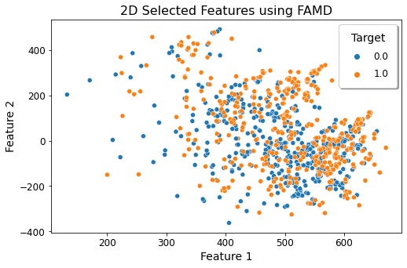

```python
fig = plt.figure(figsize=[8,5])
sns.scatterplot(x="Feature1", y="Feature2", hue='target',
                 data=balanced_X_famd_df)

plt.title("2D Selected Features using FAMD", fontsize=16)

plt.xlabel("Feature 1", fontsize=14)
plt.xticks(fontsize=12)
plt.ylabel("Feature 2", fontsize=14)
plt.yticks(fontsize=12)

plt.legend(title="Target", title_fontsize=14, fontsize=12, labelspacing= 0.8,
               borderpad=0.9, shadow=True, loc='best')
```

Even if we cannot distinguish two different clusters, one division between them can be guessed.

For the following algortihms we decided to use FAMD features instead of PCA since it seems the most natural way to go with a mixed dataset. In this way, we can avoid the step of creating dummy values that could, in some way, influence the analysis.

### Results

```python
ig_features.append('target')
```

```python
final_df
```

|  | enrollee_id | city | city_development_index | gender | relevent_experience | enrolled_university | education_level | major_discipline | experience | company_size | company_type | last_new_job | training_hours | target |
| --- | --- | --- | --- | --- | --- | --- | --- | --- | --- | --- | --- | --- | --- | --- |
| 0 | 8949 | city_103 | 0.920 | Male | 1 | no_enrollment | Graduate | STEM | 21.0 | 299.5 | Pvt Ltd | 1.0 | 36 | 1.0 |
| 1 | 29725 | city_40 | 0.776 | Male | 0 | no_enrollment | Graduate | STEM | 15.0 | 74.5 | Pvt Ltd | 5.0 | 47 | 0.0 |
| 2 | 11561 | city_21 | 0.624 | Male | 0 | Full time course | Graduate | STEM | 5.0 | 29999.5 | Pvt Ltd | 0.0 | 83 | 0.0 |
| 3 | 33241 | city_115 | 0.789 | Male | 0 | no_enrollment | Graduate | Business Degree | 0.0 | 4.5 | Pvt Ltd | 0.0 | 52 | 1.0 |
| 4 | 666 | city_162 | 0.767 | Male | 1 | no_enrollment | Masters | STEM | 21.0 | 74.5 | Funded Startup | 4.0 | 8 | 0.0 |
| ... | ... | ... | ... | ... | ... | ... | ... | ... | ... | ... | ... | ... | ... | ... |
| 19079 | 7386 | city_173 | 0.878 | Male | 0 | no_enrollment | Graduate | Humanities | 14.0 | 74.5 | Pvt Ltd | 1.0 | 42 | 1.0 |
| 19080 | 31398 | city_103 | 0.920 | Male | 1 | no_enrollment | Graduate | STEM | 14.0 | 74.5 | Pvt Ltd | 4.0 | 52 | 1.0 |
| 19081 | 24576 | city_103 | 0.920 | Male | 1 | no_enrollment | Graduate | STEM | 21.0 | 74.5 | Pvt Ltd | 4.0 | 44 | 0.0 |
| 19082 | 5756 | city_65 | 0.802 | Male | 1 | no_enrollment | High School | No Major | 0.0 | 749.5 | Pvt Ltd | 2.0 | 97 | 0.0 |
| 19083 | 23834 | city_67 | 0.855 | Male | 0 | no_enrollment | Primary School | No Major | 2.0 | 74.5 | Pvt Ltd | 1.0 | 127 | 0.0 |

19084 rows × 14 columns

```python
info_gain_df = final_df[ig_features]
df_category = info_gain_df.select_dtypes(include='object')
df_numeric = info_gain_df.select_dtypes(exclude='object')
df_category_dummies = pd.get_dummies(df_category)
frames = [df_numeric, df_category_dummies]
info_gain_df = pd.concat(frames, axis=1,join='inner')
info_gain_df.head(5)
```

|  | city_development_index | experience | last_new_job | relevent_experience | target | city_city_1 | city_city_10 | city_city_100 | city_city_101 | city_city_102 | ... | enrolled_university_Part time course | enrolled_university_no_enrollment | education_level_Graduate | education_level_High School | education_level_Masters | education_level_Phd | education_level_Primary School | gender_Female | gender_Male | gender_Other |
| --- | --- | --- | --- | --- | --- | --- | --- | --- | --- | --- | --- | --- | --- | --- | --- | --- | --- | --- | --- | --- | --- |
| 0 | 0.920 | 21.0 | 1.0 | 1 | 1.0 | 0 | 0 | 0 | 0 | 0 | ... | 0 | 1 | 1 | 0 | 0 | 0 | 0 | 0 | 1 | 0 |
| 1 | 0.776 | 15.0 | 5.0 | 0 | 0.0 | 0 | 0 | 0 | 0 | 0 | ... | 0 | 1 | 1 | 0 | 0 | 0 | 0 | 0 | 1 | 0 |
| 2 | 0.624 | 5.0 | 0.0 | 0 | 0.0 | 0 | 0 | 0 | 0 | 0 | ... | 0 | 0 | 1 | 0 | 0 | 0 | 0 | 0 | 1 | 0 |
| 3 | 0.789 | 0.0 | 0.0 | 0 | 1.0 | 0 | 0 | 0 | 0 | 0 | ... | 0 | 1 | 1 | 0 | 0 | 0 | 0 | 0 | 1 | 0 |
| 4 | 0.767 | 21.0 | 4.0 | 1 | 0.0 | 0 | 0 | 0 | 0 | 0 | ... | 0 | 1 | 0 | 0 | 1 | 0 | 0 | 0 | 1 | 0 |

5 rows × 139 columns

```python
info_gain_df['target'].value_counts()
```

```
0.0    14323
1.0     4761
Name: target, dtype: int64
```

```python
famd_df = copy.deepcopy(X_famd_df)
famd_df.head(5)
```

|  | Feature1 | Feature2 | target |
| --- | --- | --- | --- |
| 0 | 660.404724 | -140.221907 | 1.0 |
| 1 | 586.606864 | -76.018373 | 0.0 |
| 2 | 506.317255 | 224.628268 | 0.0 |
| 3 | 445.185005 | 35.373799 | 1.0 |
| 4 | 428.867227 | -149.504210 | 0.0 |

### Feature Scaling

Feature scaling is mapping the feature values of a dataset into the same range. Feature scaling is crucial for machine learning algorithms that consider distances between observations because the distance between two observations differs for non-scaled and scaled cases. There are different methods for feature scaling, including:

- **Normalization**: maps the values into the $[0, 1]$ interval

$$z = \dfrac{x-\min(x)}{\max(x) - \min(x)} $$

- **Standardization**: shifts the feature values to have a mean of zero, then maps them into a range such that they have a standard deviation of 1

$$z = \dfrac{x-\mu}{\sigma} $$

Standardization is more flexible to new values that are not yet seen in the dataset. That is why it is preferred in general. Link

```python
#scaling function

def scaling(data):

    X = data.drop(labels = "target", axis = 1)
    y = data["target"]
    X_train, X_test, y_train, y_test = train_test_split(
        X, y, test_size=0.3, random_state=109)

    scaler = StandardScaler().fit(X_train)
    X_std = scaler.transform(X)

    scaled_data = pd.DataFrame(X_std, columns=X.columns)
    scaled_data['target'] = list(y)

    return scaled_data
```

```python
info_gain_df
```

|  | city_development_index | experience | last_new_job | relevent_experience | target | city_city_1 | city_city_10 | city_city_100 | city_city_101 | city_city_102 | ... | enrolled_university_Part time course | enrolled_university_no_enrollment | education_level_Graduate | education_level_High School | education_level_Masters | education_level_Phd | education_level_Primary School | gender_Female | gender_Male | gender_Other |
| --- | --- | --- | --- | --- | --- | --- | --- | --- | --- | --- | --- | --- | --- | --- | --- | --- | --- | --- | --- | --- | --- |
| 0 | 0.920 | 21.0 | 1.0 | 1 | 1.0 | 0 | 0 | 0 | 0 | 0 | ... | 0 | 1 | 1 | 0 | 0 | 0 | 0 | 0 | 1 | 0 |
| 1 | 0.776 | 15.0 | 5.0 | 0 | 0.0 | 0 | 0 | 0 | 0 | 0 | ... | 0 | 1 | 1 | 0 | 0 | 0 | 0 | 0 | 1 | 0 |
| 2 | 0.624 | 5.0 | 0.0 | 0 | 0.0 | 0 | 0 | 0 | 0 | 0 | ... | 0 | 0 | 1 | 0 | 0 | 0 | 0 | 0 | 1 | 0 |
| 3 | 0.789 | 0.0 | 0.0 | 0 | 1.0 | 0 | 0 | 0 | 0 | 0 | ... | 0 | 1 | 1 | 0 | 0 | 0 | 0 | 0 | 1 | 0 |
| 4 | 0.767 | 21.0 | 4.0 | 1 | 0.0 | 0 | 0 | 0 | 0 | 0 | ... | 0 | 1 | 0 | 0 | 1 | 0 | 0 | 0 | 1 | 0 |
| ... | ... | ... | ... | ... | ... | ... | ... | ... | ... | ... | ... | ... | ... | ... | ... | ... | ... | ... | ... | ... | ... |
| 19079 | 0.878 | 14.0 | 1.0 | 0 | 1.0 | 0 | 0 | 0 | 0 | 0 | ... | 0 | 1 | 1 | 0 | 0 | 0 | 0 | 0 | 1 | 0 |
| 19080 | 0.920 | 14.0 | 4.0 | 1 | 1.0 | 0 | 0 | 0 | 0 | 0 | ... | 0 | 1 | 1 | 0 | 0 | 0 | 0 | 0 | 1 | 0 |
| 19081 | 0.920 | 21.0 | 4.0 | 1 | 0.0 | 0 | 0 | 0 | 0 | 0 | ... | 0 | 1 | 1 | 0 | 0 | 0 | 0 | 0 | 1 | 0 |
| 19082 | 0.802 | 0.0 | 2.0 | 1 | 0.0 | 0 | 0 | 0 | 0 | 0 | ... | 0 | 1 | 0 | 1 | 0 | 0 | 0 | 0 | 1 | 0 |
| 19083 | 0.855 | 2.0 | 1.0 | 0 | 0.0 | 0 | 0 | 0 | 0 | 0 | ... | 0 | 1 | 0 | 0 | 0 | 0 | 1 | 0 | 1 | 0 |

19084 rows × 139 columns

```python
#information gain scaling
info_gain_df = scaling(info_gain_df)
info_gain_df
```

|  | city_development_index | experience | last_new_job | relevent_experience | city_city_1 | city_city_10 | city_city_100 | city_city_101 | city_city_102 | city_city_103 | ... | enrolled_university_no_enrollment | education_level_Graduate | education_level_High School | education_level_Masters | education_level_Phd | education_level_Primary School | gender_Female | gender_Male | gender_Other | target |
| --- | --- | --- | --- | --- | --- | --- | --- | --- | --- | --- | --- | --- | --- | --- | --- | --- | --- | --- | --- | --- | --- |
| 0 | 0.743798 | 1.611529 | -0.586062 | 0.622656 | -0.035697 | -0.068287 | -0.118831 | -0.060053 | -0.122346 | 1.858135 | ... | 0.596430 | 0.772464 | -0.345432 | -0.546843 | -0.146054 | -0.127598 | -0.263295 | 0.284155 | -0.099902 | 1.0 |
| 1 | -0.419298 | 0.726466 | 1.802351 | -1.606024 | -0.035697 | -0.068287 | -0.118831 | -0.060053 | -0.122346 | -0.538174 | ... | 0.596430 | 0.772464 | -0.345432 | -0.546843 | -0.146054 | -0.127598 | -0.263295 | 0.284155 | -0.099902 | 0.0 |
| 2 | -1.647011 | -0.748640 | -1.183166 | -1.606024 | -0.035697 | -0.068287 | -0.118831 | -0.060053 | -0.122346 | -0.538174 | ... | -1.676642 | 0.772464 | -0.345432 | -0.546843 | -0.146054 | -0.127598 | -0.263295 | 0.284155 | -0.099902 | 0.0 |
| 3 | -0.314297 | -1.486193 | -1.183166 | -1.606024 | -0.035697 | -0.068287 | -0.118831 | -0.060053 | -0.122346 | -0.538174 | ... | 0.596430 | 0.772464 | -0.345432 | -0.546843 | -0.146054 | -0.127598 | -0.263295 | 0.284155 | -0.099902 | 1.0 |
| 4 | -0.491992 | 1.611529 | 1.205248 | 0.622656 | -0.035697 | -0.068287 | -0.118831 | -0.060053 | -0.122346 | -0.538174 | ... | 0.596430 | -1.294558 | -0.345432 | 1.828678 | -0.146054 | -0.127598 | -0.263295 | 0.284155 | -0.099902 | 0.0 |
| ... | ... | ... | ... | ... | ... | ... | ... | ... | ... | ... | ... | ... | ... | ... | ... | ... | ... | ... | ... | ... | ... |
| 19079 | 0.404562 | 0.578955 | -0.586062 | -1.606024 | -0.035697 | -0.068287 | -0.118831 | -0.060053 | -0.122346 | -0.538174 | ... | 0.596430 | 0.772464 | -0.345432 | -0.546843 | -0.146054 | -0.127598 | -0.263295 | 0.284155 | -0.099902 | 1.0 |
| 19080 | 0.743798 | 0.578955 | 1.205248 | 0.622656 | -0.035697 | -0.068287 | -0.118831 | -0.060053 | -0.122346 | 1.858135 | ... | 0.596430 | 0.772464 | -0.345432 | -0.546843 | -0.146054 | -0.127598 | -0.263295 | 0.284155 | -0.099902 | 1.0 |
| 19081 | 0.743798 | 1.611529 | 1.205248 | 0.622656 | -0.035697 | -0.068287 | -0.118831 | -0.060053 | -0.122346 | 1.858135 | ... | 0.596430 | 0.772464 | -0.345432 | -0.546843 | -0.146054 | -0.127598 | -0.263295 | 0.284155 | -0.099902 | 0.0 |
| 19082 | -0.209295 | -1.486193 | 0.011041 | 0.622656 | -0.035697 | -0.068287 | -0.118831 | -0.060053 | -0.122346 | -0.538174 | ... | 0.596430 | -1.294558 | 2.894930 | -0.546843 | -0.146054 | -0.127598 | -0.263295 | 0.284155 | -0.099902 | 0.0 |
| 19083 | 0.218789 | -1.191172 | -0.586062 | -1.606024 | -0.035697 | -0.068287 | -0.118831 | -0.060053 | -0.122346 | -0.538174 | ... | 0.596430 | -1.294558 | -0.345432 | -0.546843 | -0.146054 | 7.837127 | -0.263295 | 0.284155 | -0.099902 | 0.0 |

19084 rows × 139 columns

```python
#famd scaling
famd_df = scaling(famd_df)
famd_df.head(5)
```

|  | Feature1 | Feature2 | target |
| --- | --- | --- | --- |
| 0 | 1.650332 | -0.891189 | 1.0 |
| 1 | 0.870060 | -0.515722 | 0.0 |
| 2 | 0.021151 | 1.242483 | 0.0 |
| 3 | -0.625205 | 0.135708 | 1.0 |
| 4 | -0.797735 | -0.945473 | 0.0 |

```python
famd_df['target'].value_counts()
```

```
0.0    14323
1.0     4761
Name: target, dtype: int64
```

## Algorithms

Since our problem is a classification problem, we focused on the algorithm that we wanted to learn more about. In particular we decided to go with

- Support Vector Machine, in order to study the features of a mathematical model.
- Random Forest, the best option for our dataset since it's based on rules.
- Neural Network, a deep learning model for seeing if learning new features could help the prediction.

We implemented the algorithms by choosing a split of 70% of the data for train and 30% of the data for test. We tried to build the learning curves but we noticed that it took to much time to run so we decided to go with the most common choice.

### SVM

Scikit-Learn contains the svm library, which contains built-in classes for different SVM algorithms. Since we are going to perform a classification task, we will use the support vector classifier class, which is written as SVC in the Scikit-Learn's svm library.

```python
balanced_famd = balanced_X_famd_df
balanced_famd = scaling(balanced_famd)
balanced_famd.head()
```

|  | Feature1 | Feature2 | target |
| --- | --- | --- | --- |
| 0 | 1.619169 | -0.999808 | 1.0 |
| 1 | 0.835780 | -0.616882 | 0.0 |
| 2 | -0.016521 | 1.176249 | 0.0 |
| 3 | -0.665460 | 0.047488 | 1.0 |
| 4 | -0.838678 | -1.055170 | 0.0 |

```python
X = balanced_famd.drop(columns=['target'], axis = 1)
y = balanced_famd["target"]

X_train, X_test, y_train, y_test = train_test_split(X, y, test_size=0.3, random_state=109)
```

#### Parameter selection

The parameters that should be selected for a SVM model:

[figure not shown]

3. **Gamma**: Intuitively, the gamma parameter defines how far the influence of a single training example reaches, with low values meaning far and high values meaning close.

The C that brings the highest accuracy will be found for each chosen kernel. Based on accuracy and the time, the best kernel will be chosed and applied on the whole data-set.

[Source1](https://medium.com/all-things-ai/in-depth-parameter-tuning-for-svc-758215394769) [Source2](https://scikit-learn.org/stable/auto_examples/svm/plot_rbf_parameters.html) [Source3](https://stats.stackexchange.com/questions/31066/what-is-the-influence-of-c-in-svms-with-linear-kernel#:~:text=The%20C%20parameter%20tells%20the,the%20training%20points%20classified%20correctly.)

```python
grid_param = {'C': [0.1, 1, 10, 100, 1000],
              'gamma': [1, 0.1, 0.01, 0.001, 0.0001],
              'kernel': ['rbf', 'linear']}

gd_sr_svm = GridSearchCV(estimator=SVC(),
                     param_grid=grid_param,
                     scoring='accuracy',
                     cv=3,
                     n_jobs=-1)
```

```python
start_time = time.monotonic()
gd_sr_svm.fit(X_train, y_train)
end_time = time.monotonic()
print(timedelta(seconds=end_time - start_time))
```

```
0:00:02.797000
```

```python
best_parameters = gd_sr_svm.best_params_
print('Best parameters for SVM: ',best_parameters)
```

```
Best parameters for SVM:  {'C': 10, 'gamma': 0.001, 'kernel': 'rbf'}
```

```python
values = best_parameters.values()
best_parameters_list = list(values)

best_result = gd_sr_svm.best_score_
print('Best accuracy for SVM: ',best_result)
```

```
Best accuracy for SVM:  0.5928738246334813
```

Now that we found the best model, we applied it to the whole dataset.

```python
X = famd_df.drop(labels = "target", axis = 1)
y = famd_df["target"]
X_train, X_test, y_train, y_test = train_test_split(
    X, y, test_size=0.3, random_state=109)
```

```python
svm_rbf = SVC(kernel=best_parameters_list[2], C=best_parameters_list[0], gamma=best_parameters_list[1])
svm_rbf.fit(X_train, y_train)
y_pred = svm_rbf.predict(X_test)
acc_svm_famd = metrics.accuracy_score(y_test, y_pred)
print(acc_svm_famd)
```

```
0.7556758644778204
```

```python
def plot_svc_decision_function(model, ax=None, plot_support=True):
    if ax is None:
        ax = plt.gca()
    xlim = ax.get_xlim()
    ylim = ax.get_ylim()
    x = np.linspace(xlim[0], xlim[1], 30)
    y = np.linspace(ylim[0], ylim[1], 30)
    Y, X = np.meshgrid(y, x)
    xy = np.vstack([X.ravel(), Y.ravel()]).T
    P = model.decision_function(xy).reshape(X.shape)
    ax.contour(X, Y,
               P,
               colors='k',
               levels=[-1, 0, 1], alpha=1,
               linestyles=['--', '-', '--'])
```

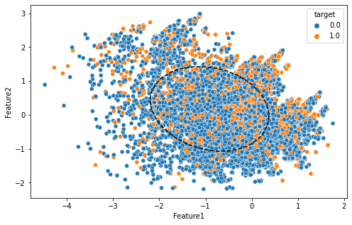

```python
plt.figure(figsize=[8,5])
plt.xlabel("Feature1")
plt.ylabel("Feature2")
sns.scatterplot(x="Feature1", y="Feature2", hue='target',
                 data=famd_df)
#plt.scatter(X.iloc[:, 0], X.iloc[:, 1], c=y, s=10)
plot_svc_decision_function(svm_rbf);
```

```
Accuracy random forest with IG selected features:  0.7556758644778204
```

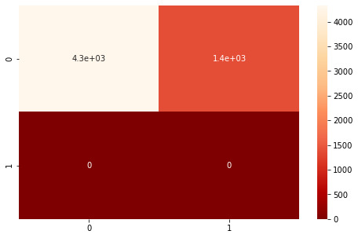

```python
print('Accuracy random forest with IG selected features: ', acc_svm_famd)

fig = plt.figure(figsize=[8,5])
cm = confusion_matrix(y_pred, y_test)
sns.heatmap(cm, annot=True, cmap="OrRd_r")
```

We didn't use SVM for information gain features because it took too much time to run.

### Random Forest

Random Forest is a learning method that operates by constructing multiple decision trees. The final decision is made based on the majority of the trees and is chosen by the random forest. For this section, the results of both preprocessing methods will be used.

There are three parameters that need to be chosen for this algorithm:

- **n_estimators**: The number of trees in the forest.
- **criterion**: The function to measure the quality of a split. Supported criteria are Gini and entropy.
- **bootstrap**: Whether bootstrap samples are used when building trees. Bootstrap sampling is a technique using which parameters like mean can be estimated for an entire population without explicitly considering each and every data point in the population.

The grid search will be used for tuning these parameters.

[Source1](https://scikit-learn.org/stable/modules/generated/sklearn.ensemble.RandomForestClassifier.html) Source2

#### Parameters Selection

```python
#parameters to be explored
grid_param_RF = {
    'n_estimators': [100, 300, 500, 800, 1000],
    'criterion': ['gini', 'entropy'],
    'bootstrap': [True, False]}

#classifier to be used
classifier = RandomForestClassifier()

#applying grid search
gd_sr_RF = GridSearchCV(estimator=classifier,
                     param_grid=grid_param_RF,
                     scoring='accuracy',
                     cv=3,
                     n_jobs=-1)
```

#### Features selected by information gain

```python
# X:the predictores
X = info_gain_df.drop(labels = "target", axis = 1)
y = info_gain_df["target"]
X_train, X_test, y_train, y_test = train_test_split(X, y, test_size=0.3, random_state=109)
```

```python
start_time = time.monotonic()
gd_sr_RF.fit(X_train, y_train)
end_time = time.monotonic()
print('Duration: ', timedelta(seconds=end_time - start_time))
```

```
Duration:  0:03:12.203000
```

```python
best_parameters = gd_sr_RF.best_params_
print('Best parameters for random forest with IG selected features: ',best_parameters)
```

```
Best parameters for random forest with IG selected features:  {'bootstrap': True, 'criterion': 'entropy', 'n_estimators': 800}
```

```python
values = best_parameters.values()
best_parameters_list = list(values)

best_result = gd_sr_RF.best_score_
print('Best accuracy of grid search for random forest with IG selected features: ', best_result)
```

```
Best accuracy of grid search for random forest with IG selected features:  0.7448714795447335
```

```
Accuracy random forest with IG selected features:  0.7528815927348935
```

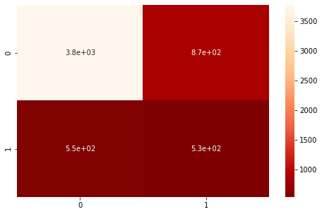

```python
# the random forest model with best parameteres
random_forest_model = RandomForestClassifier(
    n_estimators=best_parameters_list[2], criterion=best_parameters_list[1], bootstrap=best_parameters_list[0])
random_forest_model.fit(X_train, y_train)
y_pred = random_forest_model.predict(X_test)

# accuracy of model
acc_rf_ig = accuracy_score(y_test, y_pred)
print('Accuracy random forest with IG selected features: ', acc_rf_ig)

# confusion matrix
fig = plt.figure(figsize=[8,5])
cm = confusion_matrix(y_pred, y_test)
sns.heatmap(cm, annot=True, cmap="OrRd_r")
```

#### Features created by FAMD

```python
# X:the predictores
X = famd_df.drop(labels = "target", axis = 1)
y = famd_df["target"]
X_train, X_test, y_train, y_test = train_test_split(X, y, test_size=0.3, random_state=109)
```

```python
start_time = time.monotonic()
gd_sr_RF.fit(X_train, y_train);
end_time = time.monotonic()
print('Duration: ',timedelta(seconds=end_time - start_time))
```

```
Duration:  0:02:32.719000
```

```python
best_parameters = gd_sr_RF.best_params_
print('Best parameters for random forest with PCA features: ',best_parameters)
```

```
Best parameters for random forest with PCA features:  {'bootstrap': True, 'criterion': 'gini', 'n_estimators': 1000}
```

```python
values = best_parameters.values()
best_parameters_list = list(values)

best_result = gd_sr_RF.best_score_
print('Best accuracy of grid search for random forest with FAMD features: ', best_result)
```

```
Best accuracy of grid search for random forest with FAMD features:  0.7168740101181236
```

```
Accuracy for random forest with FAMD features:  0.7224938875305623
```

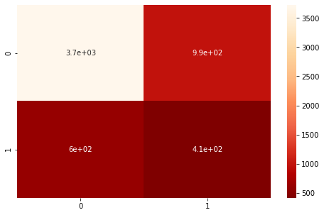

```python
# the random forest model with best parameteres
random_forest_model = RandomForestClassifier(
    n_estimators=best_parameters_list[2], criterion=best_parameters_list[1], bootstrap=best_parameters_list[0])
random_forest_model.fit(X_train, y_train)
y_pred = random_forest_model.predict(X_test)

# accuracy of model
acc_rf_famd = accuracy_score(y_test, y_pred)
print('Accuracy for random forest with FAMD features: ', acc_rf_famd)

# confusion matrix
fig = plt.figure(figsize=[8,5])
cm = confusion_matrix(y_pred, y_test)
sns.heatmap(cm, annot=True, cmap="OrRd_r")
```

### Neural Network

The main problem of building a neural network is, for sure, deciding how many hidden layers it should contain and, in addition, how many neurons a single layer should have. To solve this issue, we looked at different opinions in internet and we found an interesting hypotesys: **the majority of the problems can be solved witha single hidden layer; it is rare to improve the accuracy by adding additional layers**.

In the code below we tried to empirically prove this statement with ad additional condition: **to avoid overfitting, the number of neurons in hidden layer ($N$) should satisfy**

$$N \leq \dfrac{N_s}{(\alpha*(N_i+N_o))}$$

where

$N_s$ = number of samples in training data set;

$\alpha$ = an arbitrary scaling factor usually 2-10;

$N_i$ = number of input neurons;

$N_o$ = number of output neurons.

```python
# Function to create model, required for KerasClassifier
def create_model(input_dim, neurons=1, activation='sigmoid', dropout_rate='0.0'):
    # create model
    model = keras.Sequential()
    model.add(keras.layers.Dense(neurons, input_dim=input_dim, activation=activation))
    model.add(keras.layers.Dropout(dropout_rate))
    model.add(keras.layers.Dense(1, activation=activation))
    # Compile model
    model.compile(loss='binary_crossentropy', optimizer='adam', metrics=['accuracy'])
    return model
```

```python
def BuildNN(input_shape, num_layers, num_neurons_per_layer, dropout_rate, activ_fun):

    '''

    This function builds a neural network. It takes as input:
        - input_shape = shape of data to be processed as tuple (n,1) where
                        n:number of features
        - num_layers = number of hidden layers for the neural network
        - num_neurons = a list of ints which specifies how may neurons each layer should have.
                        The lenght of the list should be the number of layers in the NN
        - activ_fun = the function used for running the NN. Possible values are {'sigmoid',
                        'relu', 'tanh'}
        - loss_fun = the function used for computing the loss. It should be chosen according
                     to the number of neurons in the output

    '''


    #build the neural network
    model = keras.Sequential([keras.layers.Flatten(input_shape=input_shape)])

    #hidden layers
    for layer in range(num_layers):
        model.add(keras.layers.Dense(num_neurons_per_layer[layer], activation=activ_fun))
        model.add(keras.layers.Dropout(dropout_rate))

    #output layer
    model.add(keras.layers.Dense(1, activation=activ_fun))

    #compile model
    model.compile(optimizer='adam', loss='binary_crossentropy', metrics =['accuracy'])

    return model
```

#### Features selected by information gain

```python
X = info_gain_df.drop(columns=['target']).values
y = info_gain_df['target'].values

X_train, X_test, y_train, y_test = train_test_split(X, y, test_size=0.3, random_state=109)
X_train.shape
```

```
(13358, 138)
```

```python
# create model
model = KerasClassifier(build_fn=create_model, epochs=100, batch_size=10, verbose=0)

# define the grid search parameters
input_dim = (X_train.shape[1], 1)
neurons = [10, 15, 20]
activation = ['relu', 'tanh', 'sigmoid']
dropout_rate = [0.2, 0.3, 0.4]

param_grid = dict(input_dim=input_dim, neurons=neurons, activation=activation, dropout_rate=dropout_rate)
grid = GridSearchCV(estimator=model, param_grid=param_grid, n_jobs=-1, cv=3)
grid_result = grid.fit(X_train, y_train)
```

```python
# summarize results
print("Best: %f using %s" % (grid_result.best_score_, grid_result.best_params_))
```

```
Best: 0.777362 using {'activation': 'tanh', 'dropout_rate': 0.4, 'input_dim': 138, 'neurons': 20}
```

Thus, we will try to build the neural network with one layer and the parameters that grid search suggested.

```python
model = BuildNN(input_shape=(X_train.shape[1], 1), num_layers=1,
                num_neurons_per_layer=[grid_result.best_params_['neurons']],
                dropout_rate=grid_result.best_params_['dropout_rate'],
                activ_fun=grid_result.best_params_['activation'])
history = History()
model.fit(X_train, y_train, epochs = 100, batch_size=20,
          steps_per_epoch=200, verbose=0, callbacks=[history])
```

```
<tensorflow.python.keras.callbacks.History at 0x1d4cc722460>
```

```python
acc_1nn_ig = accuracy_score(model.predict_classes(X_test),y_test)
```

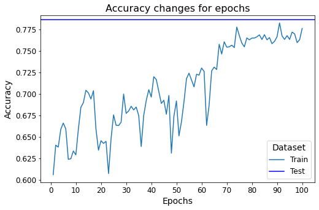

```python
fig = plt.figure(figsize=[8,5])

plt.plot(range(1,101,1), history.history['accuracy'])
plt.axhline(y=acc_1nn_ig, color='b', linestyle='-')

plt.xlabel('Epochs', fontsize=14)
plt.xticks(ticks=range(0,110,10), fontsize=12)
plt.ylabel('Accuracy', fontsize=14)
plt.yticks(fontsize=12)

plt.legend(title="Dataset", labels=['Train', 'Test'], title_fontsize=14, fontsize=12)
plt.title("Accuracy changes for epochs", fontsize=16)
```

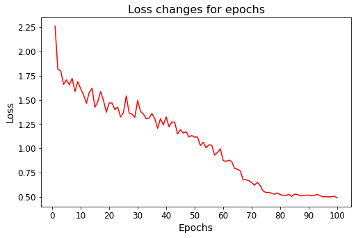

```python
fig = plt.figure(figsize=[8,5])

plt.plot(range(1,101,1), history.history['loss'], c="r")

plt.xlabel('Epochs', fontsize=14)
plt.xticks(ticks=range(0,110,10), fontsize=12)
plt.ylabel('Loss', fontsize=14)
plt.yticks(fontsize=12)

plt.title("Loss changes for epochs", fontsize=16)
```

```
Accuracy for 1-layer Neural Network with information gain features:  0.7865874956339504
```

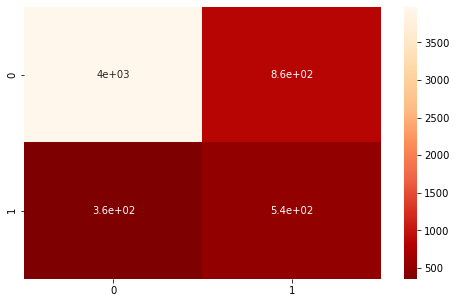

```python
y_pred = model.predict_classes(X_test)

# accuracy of model
print('Accuracy for 1-layer Neural Network with information gain features: ', acc_1nn_ig)

# confusion matrix
fig = plt.figure(figsize=[8,5])
cm = confusion_matrix(y_pred, y_test)
sns.heatmap(cm, annot=True, cmap="OrRd_r")
```

We tried to build a 2-layers neural network to see if there was any advantage.

```python
model = BuildNN((X_train.shape[1], 1), 2, [grid_result.best_params_['neurons'], grid_result.best_params_['neurons']],
                grid_result.best_params_['dropout_rate'], grid_result.best_params_['activation'])
history = History()
#history = LossHistory()
model.fit(X_train, y_train, epochs = 100, batch_size=20,
          steps_per_epoch=200, verbose=0, callbacks=[history])
```

```
<tensorflow.python.keras.callbacks.History at 0x1d48d49c2e0>
```

```python
acc_2nn_ig = accuracy_score(model.predict_classes(X_test),y_test)
```

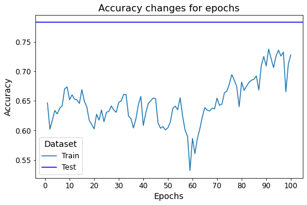

```python
fig = plt.figure(figsize=[8,5])

plt.plot(range(1,101,1), history.history['accuracy'])
plt.axhline(y=acc_2nn_ig, color='b', linestyle='-')

plt.xlabel('Epochs', fontsize=14)
plt.xticks(ticks=range(0,110,10), fontsize=12)
plt.ylabel('Accuracy', fontsize=14)
plt.yticks(fontsize=12)

plt.legend(title="Dataset", labels=['Train', 'Test'], title_fontsize=14, fontsize=12)
plt.title("Accuracy changes for epochs", fontsize=16)
```

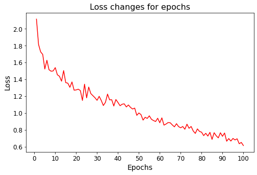

```python
fig = plt.figure(figsize=[8,5])

plt.plot(range(1,101,1), history.history['loss'], c="r")

plt.xlabel('Epochs', fontsize=14)
plt.xticks(ticks=range(0,110,10), fontsize=12)
plt.ylabel('Loss', fontsize=14)
plt.yticks(fontsize=12)

plt.title("Loss changes for epochs", fontsize=16)
```

```
Accuracy for 2-layer Neural Network with information gain features:  0.7827453719874258
```

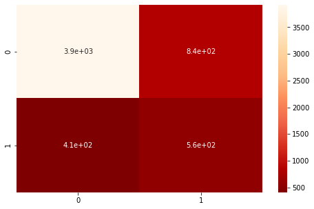

```python
y_pred = model.predict_classes(X_test)

# accuracy of model
print('Accuracy for 2-layer Neural Network with information gain features: ', acc_2nn_ig)

# confusion matrix
fig = plt.figure(figsize=[8,5])
cm = confusion_matrix(y_pred, y_test)
sns.heatmap(cm, annot=True, cmap="OrRd_r")
```

Looking at the graphics, it is clear that we don't have any big advantages in terms of accuracy in increasing the number of hidden layers. Indeed, it seems also that we could have some oferfitting problems.

#### Features created by FAMD

```python
X = famd_df.drop(columns=['target']).values
y = famd_df['target'].values

X_train, X_test, y_train, y_test = train_test_split(X, y, test_size=0.3, random_state=109)
```

```python
# create model
model = KerasClassifier(build_fn=create_model, epochs=100, batch_size=10, verbose=0)

# define the grid search parameters
input_dim = (X_train.shape[1], 1)
neurons = [10, 15, 20]
activation = ['relu', 'tanh', 'sigmoid']
dropout_rate = [0.2, 0.3, 0.4]

param_grid = dict(input_dim=input_dim, neurons=neurons, activation=activation, dropout_rate=dropout_rate)
grid = GridSearchCV(estimator=model, param_grid=param_grid, n_jobs=-1, cv=3)
grid_result = grid.fit(X_train, y_train)
```

```python
# summarize results
print("Best: %f using %s" % (grid_result.best_score_, grid_result.best_params_))
```

```
Best: 0.749588 using {'activation': 'relu', 'dropout_rate': 0.3, 'input_dim': 2, 'neurons': 20}
```

Thus, we will try to build the neural network with one layer and the parameters that grid search suggested.

```python
model = BuildNN((X_train.shape[1], 1), 1, [grid_result.best_params_['neurons']],
                grid_result.best_params_['dropout_rate'], grid_result.best_params_['activation'])
history = History()
model.fit(X_train, y_train, epochs = 100, batch_size=20,
          steps_per_epoch=200, verbose=0, callbacks=[history])
```

```
<tensorflow.python.keras.callbacks.History at 0x1d48b11ac40>
```

```python
acc_1nn_famd = accuracy_score(model.predict_classes(X_test),y_test)
```

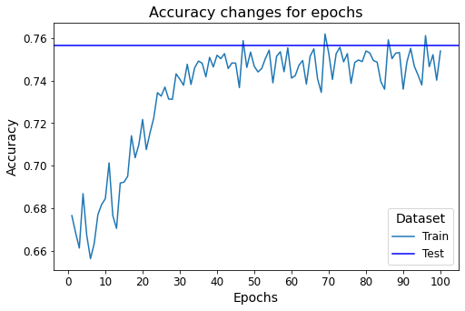

```python
fig = plt.figure(figsize=[8,5])

plt.plot(range(1,101,1), history.history['accuracy'])
plt.axhline(y=acc_1nn_famd, color='b', linestyle='-')

plt.xlabel('Epochs', fontsize=14)
plt.xticks(ticks=range(0,110,10), fontsize=12)
plt.ylabel('Accuracy', fontsize=14)
plt.yticks(fontsize=12)

plt.legend(title="Dataset", labels=['Train', 'Test'], title_fontsize=14, fontsize=12)
plt.title("Accuracy changes for epochs", fontsize=16)
```

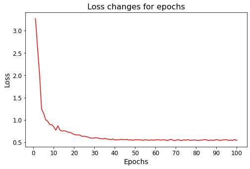

```python
fig = plt.figure(figsize=[8,5])

plt.plot(range(1,101,1), history.history['loss'], c="r")

plt.xlabel('Epochs', fontsize=14)
plt.xticks(ticks=range(0,110,10), fontsize=12)
plt.ylabel('Loss', fontsize=14)
plt.yticks(fontsize=12)

plt.title("Loss changes for epochs", fontsize=16)
```

```
Accuracyf random forest with PCA features:  0.7567237163814181
```

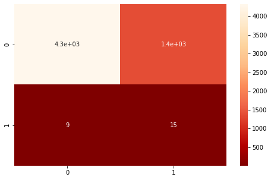

```python
y_pred = model.predict_classes(X_test)

# accuracy of model
print('Accuracyf random forest with PCA features: ', acc_1nn_famd)

# confusion matrix
fig = plt.figure(figsize=[8,5])
cm = confusion_matrix(y_pred, y_test)
sns.heatmap(cm, annot=True, cmap="OrRd_r")
```

We tried to build a 2-layers neural network to see if there was any advantage.

```python
model = BuildNN((X_train.shape[1], 1), 2, [grid_result.best_params_['neurons'], grid_result.best_params_['neurons']],
                grid_result.best_params_['dropout_rate'], grid_result.best_params_['activation'])
history = History()
#history = LossHistory()
model.fit(X_train, y_train, epochs = 100, batch_size=20,
          steps_per_epoch=200, verbose=0, callbacks=[history])
```

```
<tensorflow.python.keras.callbacks.History at 0x1d48ae1ca90>
```

```python
acc_2nn_famd = accuracy_score(model.predict_classes(X_test),y_test)
```

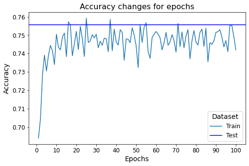

```python
fig = plt.figure(figsize=[8,5])

plt.plot(range(1,101,1), history.history['accuracy'])
plt.axhline(y=acc_2nn_famd, color='b', linestyle='-')

plt.xlabel('Epochs', fontsize=14)
plt.xticks(ticks=range(0,110,10), fontsize=12)
plt.ylabel('Accuracy', fontsize=14)
plt.yticks(fontsize=12)

plt.legend(title="Dataset", labels=['Train', 'Test'], title_fontsize=14, fontsize=12)
plt.title("Accuracy changes for epochs", fontsize=16)
```

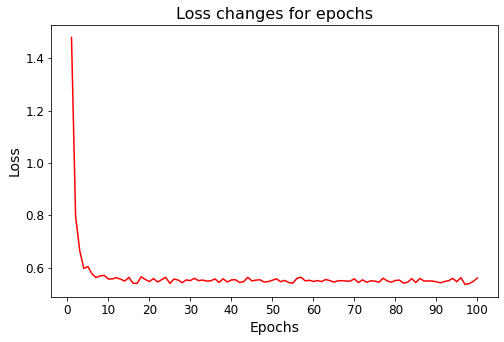

```python
fig = plt.figure(figsize=[8,5])

plt.plot(range(1,101,1), history.history['loss'], c="r")

plt.xlabel('Epochs', fontsize=14)
plt.xticks(ticks=range(0,110,10), fontsize=12)
plt.ylabel('Loss', fontsize=14)
plt.yticks(fontsize=12)

plt.title("Loss changes for epochs", fontsize=16)
```

```
Accuracyf random forest with PCA features:  0.7556758644778204
```

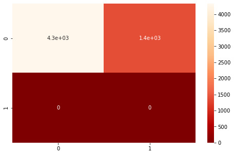

```python
y_pred = model.predict_classes(X_test)

# accuracy of model
print('Accuracyf random forest with PCA features: ', acc_2nn_famd)

# confusion matrix
fig = plt.figure(figsize=[8,5])
cm = confusion_matrix(y_pred, y_test)
sns.heatmap(cm, annot=True, cmap="OrRd_r")
```

## Conclusions

This project helped us to study in detail some of the existing algorithms for preprocessing and classification. Working using data we were not familiar with was challenging but, at the end, we were happy about the results we were able to get. This *challenge* was useful because we wanted to be prepared to any kind of real dataset from a domain we are not familiar with.

Below we summarized the main observations about the project.

### Preprocessing and Algorithms

```python
accuracy_dict = dict()
accuracy_dict['algorithms'] = ['SVM', 'SVM', 'Random Forest', 'Random Forest',
                               '1-Layer Neural Network', '1-Layer Neural Network',
                               '2-Layers Neural Network', '2-Layers Neural Network']
accuracy_dict['preprocessing'] = ['IG', 'FAMD', 'IG', 'FAMD', 'IG', 'FAMD','IG', 'FAMD']
accuracy_dict['accuracy'] = [0.0, acc_svm_famd, acc_rf_ig, acc_rf_famd,
                             acc_1nn_ig, acc_1nn_famd, acc_2nn_ig, acc_1nn_famd]

for i in range(len(accuracy_dict['accuracy'])):
    accuracy_dict['accuracy'][i] = '{:.3f}'.format(accuracy_dict['accuracy'][i])
    accuracy_dict['accuracy'][i] = float(accuracy_dict['accuracy'][i])

accuracy_df = pd.DataFrame(accuracy_dict)
```

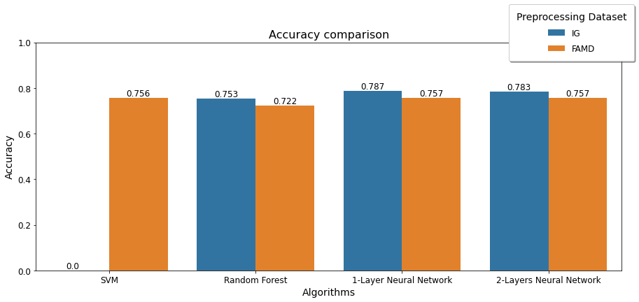

```python
#plot
fig = plt.figure(figsize=[15,6])
sns.barplot(x='algorithms', y='accuracy', hue='preprocessing', alpha=1, data=accuracy_df)

plt.text(-0.25, accuracy_df['accuracy'][0], accuracy_df['accuracy'][0], ha = 'center', va='bottom', fontsize=12)
plt.text(0.2, accuracy_df['accuracy'][1], accuracy_df['accuracy'][1], ha = 'center', va='bottom', fontsize=12)
plt.text(0.8, accuracy_df['accuracy'][2], accuracy_df['accuracy'][2], ha = 'center', va='bottom', fontsize=12)
plt.text(1.20, accuracy_df['accuracy'][3], accuracy_df['accuracy'][3], ha = 'center', va='bottom', fontsize=12)
plt.text(1.80, accuracy_df['accuracy'][4], accuracy_df['accuracy'][4], ha = 'center', va='bottom', fontsize=12)
plt.text(2.20, accuracy_df['accuracy'][5], accuracy_df['accuracy'][5], ha = 'center', va='bottom', fontsize=12)
plt.text(2.80, accuracy_df['accuracy'][6], accuracy_df['accuracy'][6], ha = 'center', va='bottom', fontsize=12)
plt.text(3.20, accuracy_df['accuracy'][7], accuracy_df['accuracy'][7], ha = 'center', va='bottom', fontsize=12)

plt.title("Accuracy comparison", fontsize=16)

plt.xlabel("Algorithms", fontsize=14)
plt.xticks(fontsize=12)
plt.ylabel("Accuracy", fontsize=14)
plt.yticks(fontsize=12)
plt.ylim(0, 1)

plt.legend(title="Preprocessing Dataset", title_fontsize=14, fontsize=12, labelspacing= 0.8,
            borderpad=0.9, shadow=True, bbox_to_anchor=(0.8, 0.9))
```

### Accuracy of Missing Values Prediction

We run the algorithms for the dataset with predicted missing values and with the one in which we deleted them. In both cases the best algorithm was the Neural Network with 1 hidden layer that used the feature selected by Information Gain and the worst was the Random Forest that used FAMD features. In general, accuracy values of the dataset with no missing data are higher. Thus, we can say that the prediction of missing values was not so accurate. However, we succeded in maintaining accuracy values higher than 0.7 also using the cleaned dataset.

In conlusion, in a real world situation we would have preferred the dataset without missing values since also with the deletion we had enough data to compute predictions.

### Difficulties and Future Works

The main difficulties we found can be grouped into two categories: hardware and software. Unfortunately, our computers were not able to handle some of the algorithms. For this reason, for example, we cannot use SVM for Information Gain dataset or use cross validation with cv more than 3. From a software point of view, we noticed that for every decision we had to make, there were too many options that were almost the same and that made the selection process really challenging. Another main problem was deu to the dataset itself. Indeed, there was no high correlation among the features and the features that were supposed to be related to the target (like training hours) were not so important. Additionally, the umbalancement of the dataset made our predictions biased on the most common target.

One analysis that we wanted to do was looking for gender discrimination into our dataset. However, the percentage of females candidate was really low (6,5%) thus, this dataset was not the best choice for such an analysis. We wanted to do a gender analysis related to a domain which is not domestic violence or fashion but most of the datasets we found care about gender in this context. One more appropriate dataset would have been a study of salary of data scientists where the gender is specified. We were really happy to extend our work in a topic like that.